# Worked Example: Air Quality

Johan Larsson

Behnaz Pirzamanbein

Jonas Wallin

# 1 Air Quality in New York

As soon as you encounter two numeric variables, your first instinct should always be visualizing them on a scatter plot. For example, the `airquality` dataset, which includes air quality measurements from New York between May and September 1973, presents such an opportunity.

The variables in this data set are

- `Ozone`: Mean ozone in parts per billion from 1300 to 1500 hours at Roosevelt Island
- `Solar.R`: Solar radiation in Langleys in the frequency band 4000–7700 Angstroms from 0800 to 1200 hours at Central Park
- `Wind`: Average wind speed in miles per hour at 0700 and 1000 hours at LaGuardia Airport
- `Temp`: Maximum daily temperature in degrees Fahrenheit at La Guardia Airport.
- `Day`, `Month`: Self-explanatory.

Here are the first few rows of the data set.

```r
head(airquality)
```

```
##   Ozone Solar.R Wind Temp Month Day
## 1    41     190  7.4   67     5   1
## 2    36     118  8.0   72     5   2
## 3    12     149 12.6   74     5   3
## 4    18     313 11.5   62     5   4
## 5    NA      NA 14.3   56     5   5
## 6    28      NA 14.9   66     5   6
```

Let’s begin by studying how wind affects air pollution, specifically the level of ozone, in the air. Take a minute to consider how you would map the variables to the axes to study this relationship.

Well, our layman intuition tells us that it’s likely that the wind affects air pollution, and not the other way around, so the natural mapping here is to place wind speed on the x axis and ozone on the y axis.

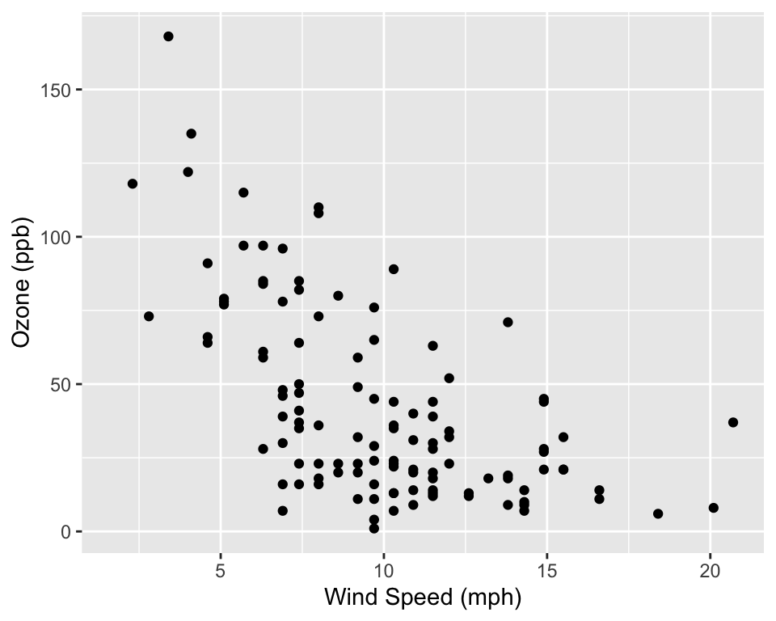

```r
library(tidyverse)

airquality %>%
  ggplot(aes(Wind, Ozone)) +
  geom_point() +
  labs(x = "Wind Speed (mph)", y = "Ozone (ppb)")
```

There is clearly a strong negative relationship between wind speed and ozone — as wind speed increases, air quality seems to improve. That’s hardly surprising if you think about it. But what kind of relationship is this? Describing it as a linear relationship is not accurate.

The downward curvature suggests that a straight line may be too restrictive. An *inverse* relationship, such as
$$\text{ozone} = \frac{c}{\text{wind speed}}$$
for some constant $c$, is one possible model, but the scatter plot alone does not establish this particular form.

## 1.1 Linear Regression and LOESS

Scatter plots show the variation between individual days. Adding a fitted line helps us see the average trend. With `geom_smooth()`, we can compare two choices:

- `method = "lm"` fits a straight line by least squares.
- `method = "loess"` fits local regressions, allowing the curve to bend.

### 1.1.1 Adding the Fits as Layers

Let’s begin with the wind–ozone scatter plot. Slightly transparent points make overlapping observations easier to see.

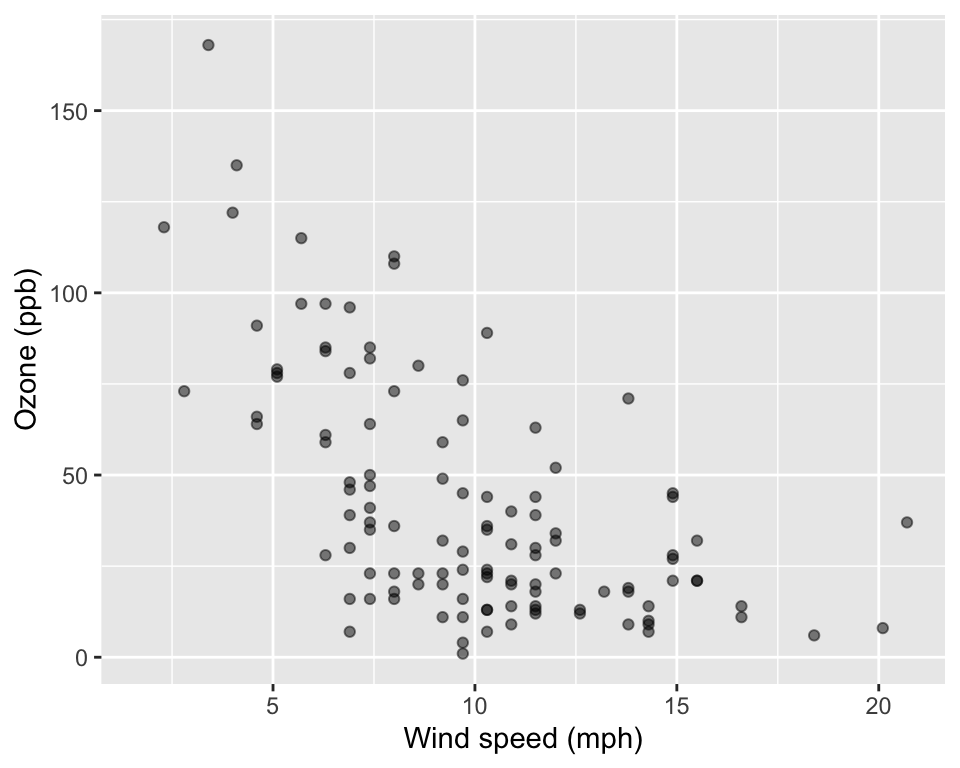

```r
ozone_wind <-
  ggplot(airquality, aes(x = Wind,y = Ozone)) +
  geom_point(alpha = 0.5) +
  labs(x = "Wind speed (mph)", y = "Ozone (ppb)")
print(ozone_wind)
```

A ggplot layer can be saved as an object and reused. We will use a dashed blue line for linear regression and a solid orange curve for LOESS.

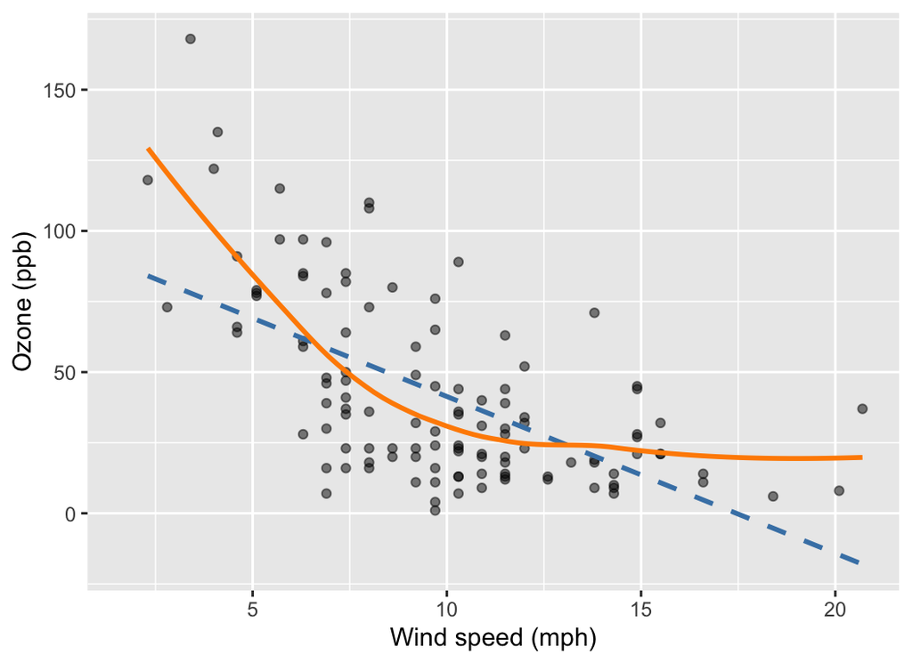

```r
linear_fit <- geom_smooth(
  method = "lm", formula = y ~ x, se = FALSE,
  colour = "steelblue", linetype = "dashed"
)

loess_fit <- geom_smooth(
  method = "loess", formula = y ~ x, span = 0.75, se = FALSE,
  colour = "darkorange"
)

ozone_wind + linear_fit + loess_fit
```

Here, `x` and `y` refer to the variables mapped to the axes. A LOESS `span` of `0.75` uses roughly three quarters of the observations for each local fit. Smaller values give more flexible curves, while larger values give smoother curves. We use `se = FALSE` to hide the confidence bands and make the two fitted trends easier to compare. Each fit uses the observations with both plotted variables available.

## 1.2 Comparing All Six Relationships

Take some time to plot the associations between `Ozone`, `Solar.R`, `Wind`, and `Temp` and try to identify any patterns you observe.

There are six distinct pairs among the four variables. We can put the pairs in a tibble and define each axis label once. Here we use a bit more advanced coding to visualize the data.

```r
variable_labels <- c(
  Ozone = "Ozone (ppb)",
  Solar.R = "Solar radiation\n(Langleys)",
  Wind = "Wind speed (mph)",
  Temp = "Temperature (F)"
)

plot_pairs <- tribble(
  ~x,        ~y,
  "Wind",    "Ozone",
  "Temp",    "Ozone",
  "Solar.R", "Ozone",
  "Wind",    "Temp",
  "Solar.R", "Temp",
  "Solar.R", "Wind"
)

scatter_plot <- function(x, y) {
  ggplot(airquality, aes(x = .data[[x]], y = .data[[y]])) +
    geom_point(alpha = 0.5) +
    labs(x = variable_labels[[x]], y = variable_labels[[y]])
}

plot_pairs <- plot_pairs %>%
  mutate(scatter = map2(x, y, scatter_plot))
```

The entries in `x` and `y` are column names stored as strings; `.data[[x]]` selects the corresponding column inside `aes()`. `map2()` calls `scatter_plot()` for each pair and stores the plots in a list-column named `scatter`. We can pass that list directly to **patchwork**.

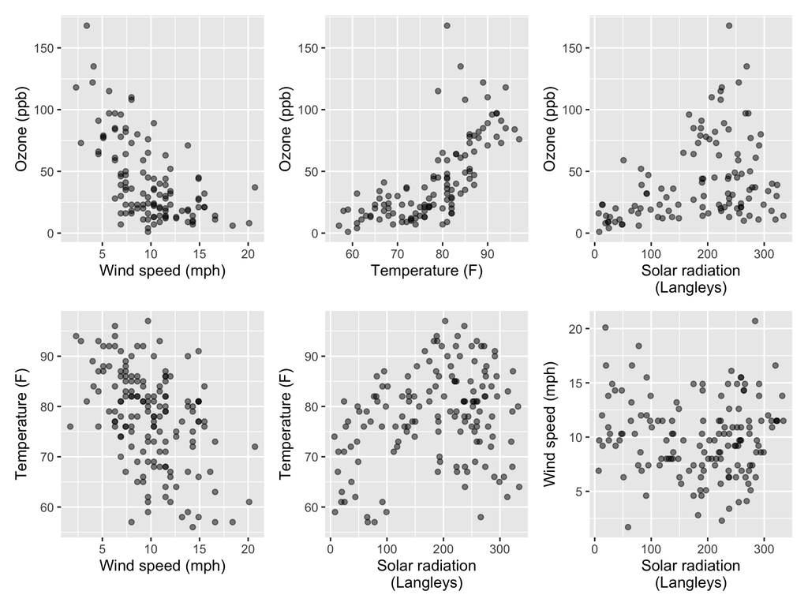

```r
library(patchwork)

wrap_plots(plot_pairs$scatter, ncol = 3)
```

Which relationships look roughly linear, and which suggest curvature?

### 1.2.1 Adding Fits to All Six Relationships

We can extend `scatter_plot()` with the fitted layers and reuse the same tibble to compare the trends across all six relationships.

```r
trend_plot <- function(x, y) {
  scatter_plot(x, y) +
    linear_fit +
    loess_fit
}

plot_pairs <- plot_pairs %>%
  mutate(plot = map2(x, y, trend_plot))
```

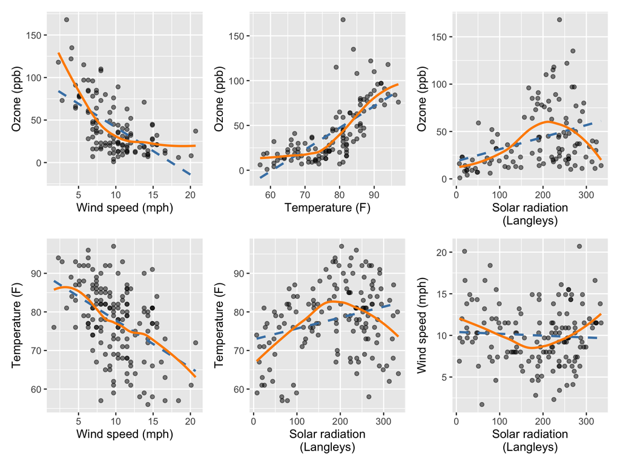

```r
wrap_plots(plot_pairs$plot, ncol = 3)
```

Where does a straight line capture the main trend, and where does LOESS reveal curvature? Which relationships still show considerable scatter? Try changing the LOESS `span` to `0.5` or `1` and see which features remain visible.

### 1.2.2 Adding Confidence Bands

Now replace the fitted layers with versions using `se = TRUE`, then reuse `trend_plot()` to draw all six relationships again. With `level = 0.95`, the shading shows 95% confidence intervals for the estimated mean trend at each x value; the LOESS intervals are approximate. Individual days can vary much more than the width of these bands.

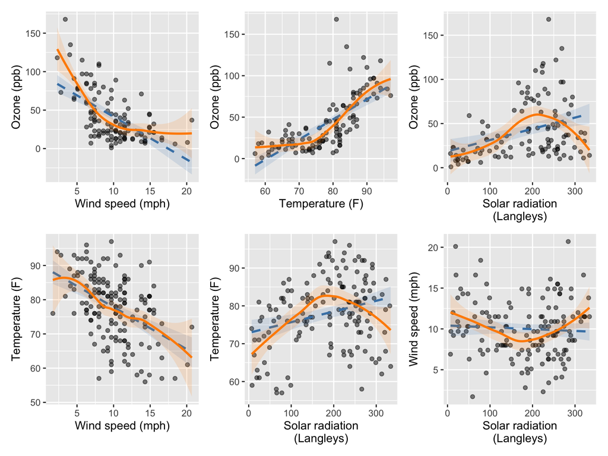

```r
linear_fit <- geom_smooth(
  method = "lm", formula = y ~ x, se = TRUE, level = 0.95,
  colour = "steelblue", fill = "steelblue", alpha = 0.15,
  linetype = "dashed"
)

loess_fit <- geom_smooth(
  method = "loess", formula = y ~ x, span = 0.75, se = TRUE, level = 0.95,
  colour = "darkorange", fill = "darkorange", alpha = 0.15
)

plot_pairs <- plot_pairs %>%
  mutate(plot_with_bands = map2(x, y, trend_plot))

wrap_plots(plot_pairs$plot_with_bands, ncol = 3)
```

## 1.3 Longitudinal Data

These data are longitudinal in nature, so examining how these measures vary over time is a reasonable approach. First, however, we need to combine the day and month variables into a single variable representing time. To do this, we can use the handy `make_date()` function from the **lubridate** package.

```r
library(lubridate)

airquality_formatted <-
  airquality %>%
  as_tibble() %>% # tibbles are nicer to work with than data frames, do you know why?
  mutate(Date = make_date("1973", Month, Day))

airquality_formatted
```

```
## # A tibble: 153 × 7
##    Ozone Solar.R  Wind  Temp Month   Day Date
##    <int>   <int> <dbl> <int> <int> <int> <date>
##  1    41     190   7.4    67     5     1 1973-05-01
##  2    36     118   8      72     5     2 1973-05-02
##  3    12     149  12.6    74     5     3 1973-05-03
##  4    18     313  11.5    62     5     4 1973-05-04
##  5    NA      NA  14.3    56     5     5 1973-05-05
##  6    28      NA  14.9    66     5     6 1973-05-06
##  7    23     299   8.6    65     5     7 1973-05-07
##  8    19      99  13.8    59     5     8 1973-05-08
##  9     8      19  20.1    61     5     9 1973-05-09
## 10    NA     194   8.6    69     5    10 1973-05-10
## # ℹ 143 more rows
```

Now we’re ready to explore the data. The primary focus of this data set is air quality, so our main interest is in examining ozone levels over time.

Here is our first attempt: we will use the line geom, which is a natural choice for visualizing this type of data.

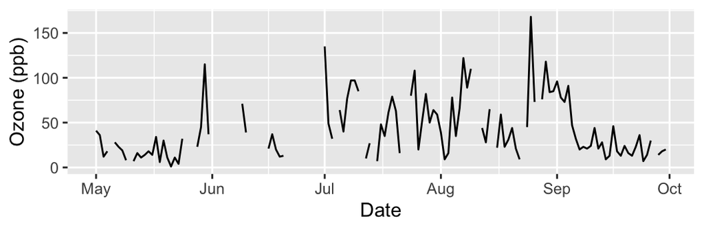

```r
p1 <-
  airquality_formatted %>%
  ggplot(aes(Date, Ozone)) +
  geom_line() +
  labs(y = "Ozone (ppb)")

p1
```

The result is possibly not quite as nice as you’d expect. Can you figure out why there are multiple holes in the plot?

Missing ozone values break the line. An observed value surrounded by missing values has no line segment, so it is invisible without a point geom.

Dropping the missing values allows the remaining observations to connect, even when there are missing days between them.

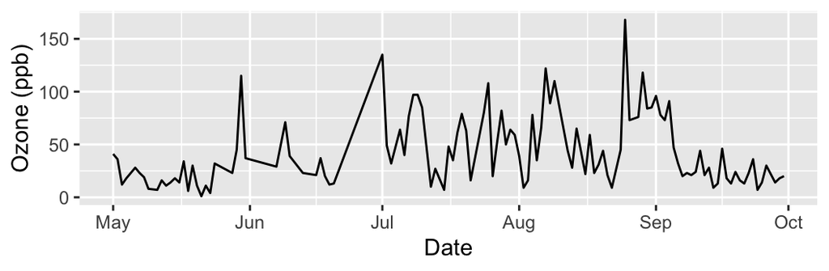

```r
airquality_nona <- drop_na(airquality_formatted, Ozone)

p2 <-
  airquality_nona %>%
  ggplot(aes(Date, Ozone)) +
  geom_line() +
  labs(y = "Ozone (ppb)")

p2
```

Adding a point geom shows which dates have observed measurements, although the lines still connect across missing days.

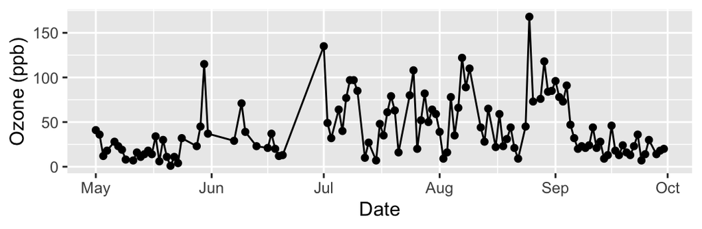

```r
p3 <- p2 + geom_point()
p3
```

### 1.3.1 Keeping Gaps for Missing Observations

To leave gaps where ozone measurements are missing, we can add points to `p1`. This plot still uses the original data, including the missing values, so the line breaks at each missing measurement. The points show all observed values. Setting `na.rm = TRUE` on the point geom silently omits missing points without changing the line layer.

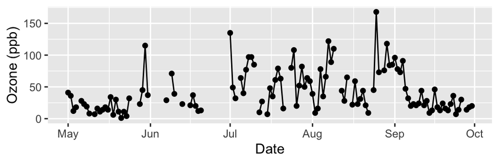

```r
p_gaps <- p1 + geom_point(na.rm = TRUE)
p_gaps
```

Compare this with `p3`: where does `p3` connect observations across missing days?

### 1.3.2 Air Pollution across the Week

One aspect currently missing from the visualization, which could provide further insight, is the relationship between air pollution and the type of day — specifically, distinguishing between weekdays and weekends. A possible solution for this might be to color the weekend days differently. However, in this case, we’ll use the grid and axis ticks to display this information. We can achieve this by specifying scales with `scale_x_date()` and inputting `"weeks"` into the `minor_breaks` argument.

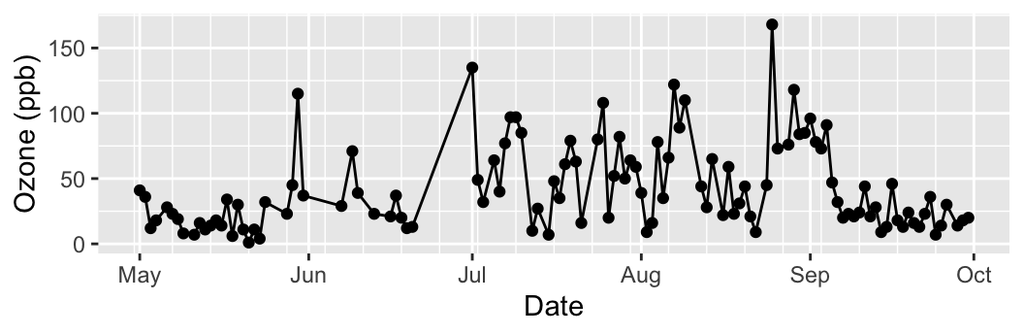

```r
p4 <- p3 + scale_x_date(minor_breaks = "weeks")
p4
```

Unfortunately, it is hard to see a clear pattern here, likely because air pollution varies significantly from day to day due to other factors. A possible way to solve this is to create a new variable, `Weekday`, in our data set, representing the day of the week. For this purpose, we use the `wday()` function from lubridate.

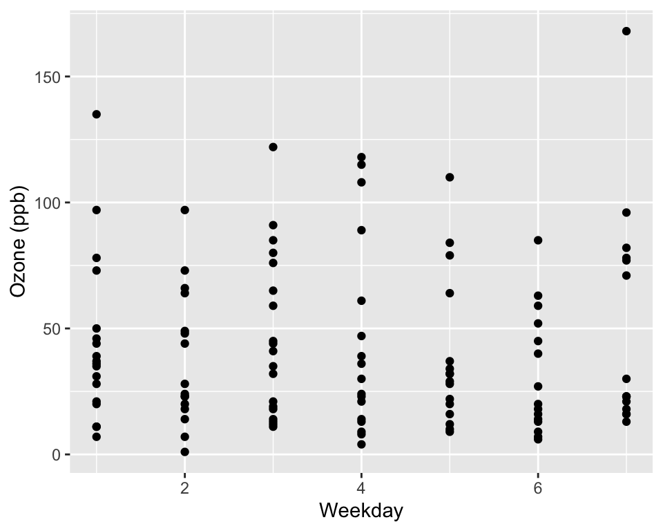

```r
airquality_1973 <-
  airquality_nona %>%
  mutate(Weekday = wday(Date))

airquality_1973 %>%
  ggplot(aes(Weekday, Ozone)) +
  geom_point() +
  labs(y = "Ozone (ppb)")
```

Great, but now the point geom is probably not the best candidate for this job, specially without adjustments like jittering and/or opacity. A better alternative could be to use box plots. To effectively use box plots, we need to convert the `Weekday` variable into a factor variable. Ensuring the correct order of days, we’ll use `as.ordered()`. This conversion can be done directly in the `ggplot()` call. However, it’s important to note that this approach requires manually adjusting the axis label, as it will default to `"as.ordered(Weekday)"` otherwise.

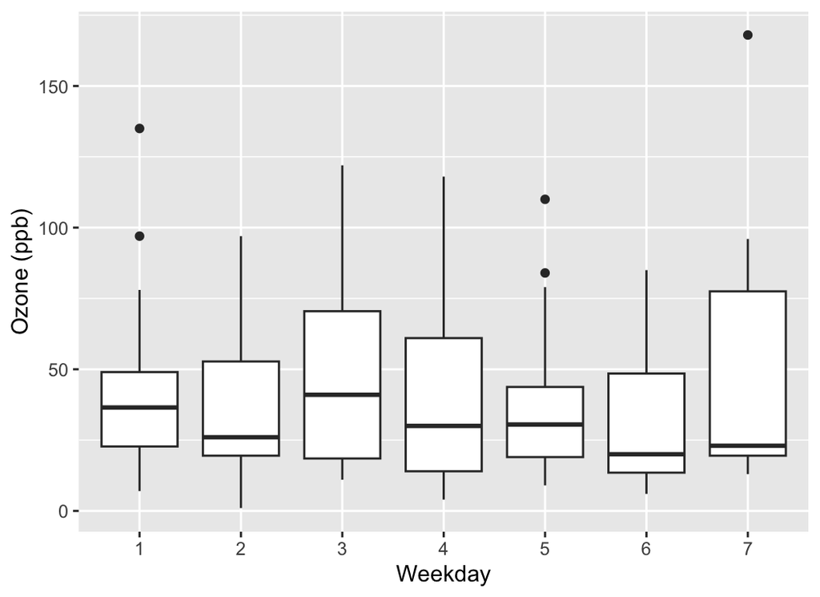

```r
airquality_1973 %>%
  ggplot(aes(as.ordered(Weekday), Ozone)) +
  geom_boxplot() +
  labs(x = "Weekday", y = "Ozone (ppb)")
```

There is no clear pattern across the days of the week. Do the box plots suggest any consistent difference between weekends and other days?

Additionally, take some time to visualize the relationships between time and the other variables in the data set.

### 1.3.3 Using Day Names on the Axis

The weekday plots above use numbers on the x axis. With the default `wday()` settings, `1` means Sunday, `2` means Monday, and so on, up to `7` for Saturday. Using day names instead makes it easier to identify the weekdays and weekends.

In the previous box plot, `as.ordered(Weekday)` turns the numbers into factor levels, so `ggplot2` draws a separate box for each day. It uses the existing numeric order; it does not discover the calendar order. A regular factor would also provide separate groups for the box plots.

We can use `wday()` to create the day names directly by setting `label = TRUE`. This returns an ordered factor, so we no longer need `as.ordered()` inside `aes()`. Setting `week_start = 7` keeps Sunday first, matching the earlier plots. We also use `locale = "C"` to get English day names regardless of the computer’s language settings.

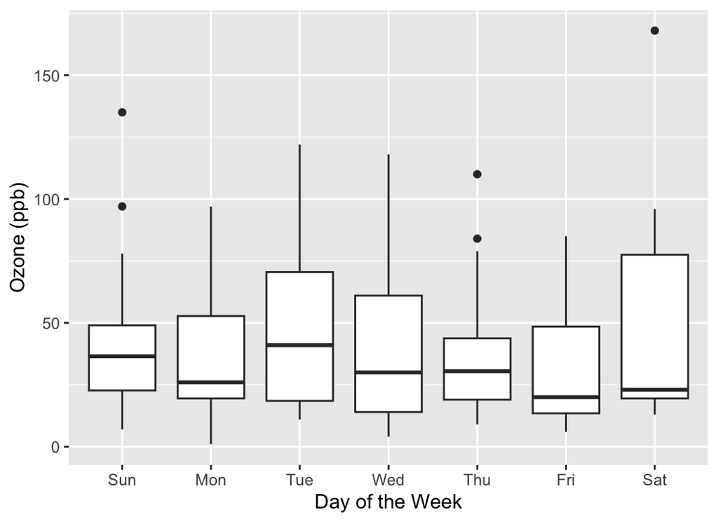

```r
airquality_1973_named <-
  airquality_nona %>%
  mutate(Weekday = wday(Date, label = TRUE, week_start = 7, locale = "C"))

airquality_1973_named %>%
  ggplot(aes(Weekday, Ozone)) +
  geom_boxplot() +
  labs(x = "Day of the Week", y = "Ozone (ppb)")
```

To display Monday first instead, change `week_start` to `1`. Compare the numbered and named plots: have the observations or box-plot summaries changed, or only the axis labels?

### 1.3.4 Weekend and Non-weekend Summary

Let’s compare weekends (Saturday and Sunday) with other days, using the observed ozone measurements. The mean and median are in ppb.

```r
airquality_1973_named %>%
  mutate(DayType = if_else(Weekday %in% c("Sat", "Sun"), "Weekend", "Non-weekend")) %>%
  group_by(DayType) %>%
  summarise(
    Observations = n(),
    Mean_Ozone = round(mean(Ozone), 1),
    Median_Ozone = median(Ozone),
    .groups = "drop"
  )
```

```
## # A tibble: 2 × 4
##   DayType     Observations Mean_Ozone Median_Ozone
##   <chr>              <int>      <dbl>        <int>
## 1 Non-weekend           83       40.2           30
## 2 Weekend               33       47.1           35
```

### 1.3.5 Comparing Months

The time-series plots suggest higher ozone levels in the summer. Let’s compare the monthly distributions using box plots.

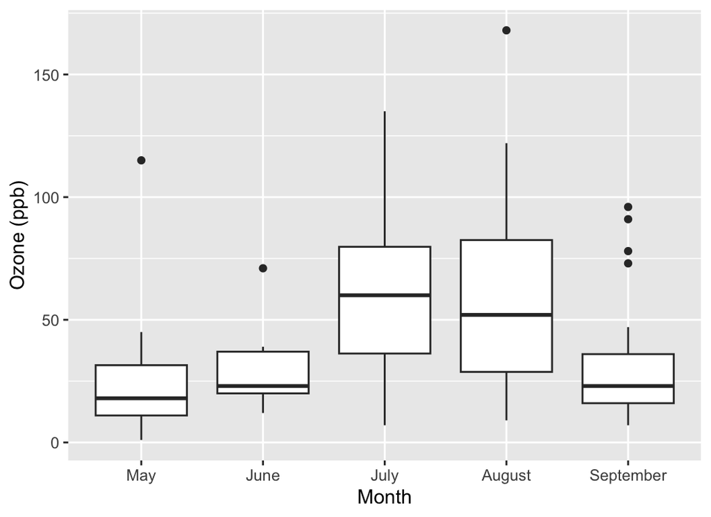

```r
airquality_month_named <-
  airquality_formatted %>%
  mutate(Month = factor(Month, levels = 5:9, labels = month.name[5:9]))

airquality_month_named %>%
  ggplot(aes(Month, Ozone)) +
  geom_boxplot(na.rm = TRUE) +
  labs(x = "Month", y = "Ozone (ppb)")
```

We can also count observed and missing ozone measurements in each month. The mean and median use only observed values and are in ppb.

```r
airquality_month_named %>%
  group_by(Month) %>%
  summarise(
    Observations = sum(!is.na(Ozone)),
    Missing = sum(is.na(Ozone)),
    Mean_Ozone = round(mean(Ozone, na.rm = TRUE), 1),
    Median_Ozone = median(Ozone, na.rm = TRUE),
    .groups = "drop"
  )
```

```
## # A tibble: 5 × 5
##   Month     Observations Missing Mean_Ozone Median_Ozone
##   <fct>            <int>   <int>      <dbl>        <dbl>
## 1 May                 26       5       23.6           18
## 2 June                 9      21       29.4           23
## 3 July                26       5       59.1           60
## 4 August              26       5       60             52
## 5 September           29       1       31.4           23
```

Which months have higher ozone levels, and how much do their distributions overlap? Notice that June has only nine observed values; its summary is based on much less data.

# 2 Source Code

The source code for this document is available at https://github.com/stat-lu/dataviz/blob/main/worked-examples/airquality.Rmd.